# Case Study 1: College Basketball

prepared by Kelly Bodwin

In this Case Study, you will refresh your memory of STOR 155 while you learn some basic commands and tools for analyzing data with **R**. We’ll be looking at some data from college basketball games last year.

Run the following **R** code to load the data into your RStudio and take a look at it.

## Summarizing data

```r
# Load dataset
bball = read.csv("http://kbodwin.web.unc.edu/files/2016/06/basketball.csv")

# Look at dataset
head(bball)
```

```
##   X     Date         Team Team.Location Team.Score     Opponent
## 1 1 11/13/15 Old Dominion       Neutral         67      Niagara
## 2 2 11/13/15      Niagara       Neutral         50 Old Dominion
## 3 3 11/13/15 Sacred Heart       Neutral         76   Quinnipiac
## 4 4 11/13/15   Quinnipiac       Neutral         64 Sacred Heart
## 5 5 11/13/15        Texas       Neutral         71   Washington
## 6 6 11/13/15 Wright State       Neutral         77 South Dakota
##   Opponent.Score Team.Result
## 1             50         Win
## 2             67        Loss
## 3             64         Win
## 4             76        Loss
## 5             77        Loss
## 6             69         Win
```

```r
summary(bball)
```

```
##        X               Date                       Team
##  Min.   :    1   11/13/15: 310   Akron              :   35
##  1st Qu.: 2914   2/6/16  : 306   Austin Peay        :   35
##  Median : 5827   1/9/16  : 300   Bowling Green State:   35
##  Mean   : 5827   1/16/16 : 288   Buffalo            :   35
##  3rd Qu.: 8740   1/30/16 : 286   Fresno State       :   35
##  Max.   :11653   2/13/16 : 286   Green Bay          :   35
##                  (Other) :9877   (Other)            :11443
##  Team.Location    Team.Score                    Opponent
##  Away   :5240   Min.   : 25.00   Akron              :   35
##  Home   :5251   1st Qu.: 64.00   Austin Peay        :   35
##  Neutral:1162   Median : 72.00   Bowling Green State:   35
##                 Mean   : 72.54   Buffalo            :   35
##                 3rd Qu.: 81.00   Fresno State       :   35
##                 Max.   :144.00   Green Bay          :   35
##                                  (Other)            :11443
##  Opponent.Score   Team.Result
##  Min.   : 25.00   Loss:5821
##  1st Qu.: 64.00   Win :5832
##  Median : 72.00
##  Mean   : 72.51
##  3rd Qu.: 81.00
##  Max.   :144.00
##
```

The command `read.csv( )` will read a dataset into R from your computer or from online. “csv” stands for “comma separated value”, a common file type where the data is listed in a text file, with variables separated by commas. For now, you don’t need to worry about the details of `read.csv( )`. Once you have loaded the data, the command `summary( )` will tell you about the variables in the dataset and their values. Another useful function is `head( )`, which shows you the first 6 rows of the dataset.

### Question 1:

1. Look at the outputs of `summary(bball)` and `head(bball)`, and describe the variables using vocabulary from STOR 155.

   ```
   Categorical, Quantitative
   ```

2. If `head( )` shows the first 6 rows of the dataset, what command do you think might show the *last* 6 rows? Try out your proposed function and see what happens

   ```
   tail()
   ```

3. Try the commands `ncol( )` and `nrow( )`. What do these do? How could you get the same information from `head( )`, `summary( )`, and/or the command you figured out in part (b)?

   ```
   Count the different headings from head() or summary() for ncol(), largest x from tail() or max X from summary() for nrow()
   ```

Sometimes, we will want to look at individual entries, rows, or columns of our data matrix. We can do this using brackets `[ ]` after our dataset. We can also look at a variables (columns) by name using the *$* symbol. Try the following examples.

```r
# Look at a single row
bball[123, ]

# Look at a single column
bball[ , 4]
bball$Team.Score

# Look at a single entry
bball[123, 4]
bball$Team.Score[123]

# Calculate mean, median, variance, and standard deviation
mean(bball$Team.Score)
median(bball$Team.Score)
var(bball$Team.Score)
sd(bball$Team.Score)
```

### Question 2:

1. What is the difference between `mean(bball$Team.Score)` and `mean(bball[,4])`? Why might it be useful to have two ways to get access the variable `Team.Score`?

   ```
   bball[,4] is non-numerical. mean(bball[,5]) is exactly the same as mean(bball$Team.Score). Accessing by index is useful for programmatic access, by name is useful for readability.
   ```

2. In plain English, what were the events of the game represented by the first row of the dataset?

   ```
   When it occurred, who played who, whether it was played at one of the team's courts or elsewhere, and final score, and who won
   ```

   *(Note: If you don’t know much about basketball - for example, if you don’t know what it means to play a game “Home” versus “Away” - ask people around you.)*

All these commands we have been using, like `summary( )` and `mean( )` are called *functions*. A function can take all different kinds of input depending on what you are trying to do: datasets, vectors such as `bball$Team.Score`, etc. An important skill in **R** is figuring out for yourself how functions work.

For example, type `?boxplot` into your **R** console. A help page will pop up telling you about this function. Notice that under **Usage**, it says `boxplot(x, ...)`. This tells you that you need to supply something called *x* to the function, and the rest of the input is optional. But what is *x*? Ah-ha! There is a section called **Arguments**, which tells us that *x* is the vector of values you want to put in a boxplot.

Run the code below to make a boxplot of the team scores of college basketball games.

```r
# make boxplot of team scores
boxplot(bball$Team.Score)
```

### Question 3:

1. Now check out `?hist`, a function for making histograms. Below is basic code to make a histogram of `Team.Scores`, and also code for the same histogram but with a lot of the optional input changed. Mess around with these inputs until you understand what each is doing.

```r
# Boring histogram
hist(bball$Team.Score)

# Fancy histogram
hist(bball$Team.Score, breaks = 5, main = "I am a title",
     xlab = "I am an x-axis label", col = "grey", freq = FALSE)
```

Explain in your own words what `breaks` and `freq` change about the histogram.

```
freq uses frequency instead of density for vertical axis. breaks dictates the number of breaks in the histogram.
```

2. The optional inputs `main`, `xlab`, `ylab`, and `col` are common to most plotting functions. Use what you learned in (a) to make a boxplot of `Team.Scores` with proper axis labels and title.

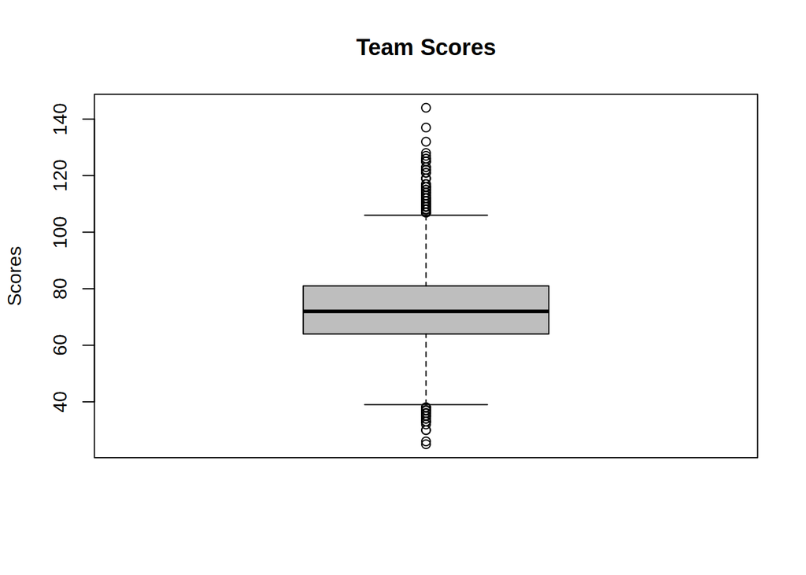

```r
# make boxplot of team scores
boxplot(bball$Team.Score, main="Team Scores", ylab="Scores", col="grey")
```

3. To check if the histogram is Normal, or to help visualize its shape, we might want to overlay a Normal curve on top of the histogram. The code below will do so - but the curve doesn’t fit very well.

```r
# Boring histogram
hist(bball$Team.Score, freq = FALSE)

# overlay Normal Curve

curve(dnorm(x, mean=120, sd=20),
      add = TRUE, col = "blue", lwd = 2)
```

Explain what the role is of the functions `curve( )` and `dnorm( )`. Why did we put `add = TRUE` in the inputs?

```
dnorm() calculates a normal distribution fiven params. curve() creates a curve from given data and params.
```

4. Alternatively, we can overlay a line that is a “smoothed” version of the data, as follows:

```r
# overlay smoothed curve
lines(density(bball$Team.Score),
      col = "red", lwd = 2, lty = 2)
```

What is the difference between `lines( )` and `curve( )`? When might we want to use `density( )`, and when would it be better to overlay a Normal curve on a histogram?

```
lines() creates a smooth curve of connected line segments whereas curve() creates a solid normal curve.
```

5. Now make your own histogram with well-chosen inputs and with a Normal overlay that fits better. Would you say the data looks Normal?

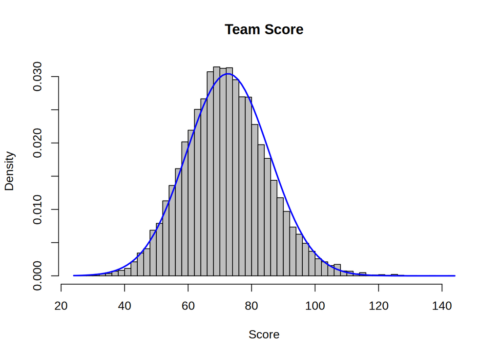

```r
hist(bball$Team.Score, breaks=50, main="Team Score", xlab="Score", col="grey", freq=FALSE)
curve(dnorm(x, mean=mean(bball$Team.Score), sd=sd(bball$Team.Score)), add=TRUE, col="blue", lwd=2)
```

```r
# Yes, the data looks normal
```

## Subsetting

One of the most powerful qualities of **R** is the ability to select a subset of a dataset. Suppose we want to look only at games involving UNC or Duke. We would need to figure out which rows of `bball` involve one of those teams, and then make a new dataset out of only those rows.

For this, we will use *booleans*, which are variables with the value `TRUE` or `FALSE`. Play around with the following code until you feel comfortable with `==`, `>`, `<`, and `%in%` as well as `&` (and) and `|` (or).

```r
# booleans practice

1 == 1
1 == 2
1 < 2

1 == 1 | 1  > 2
1 == 1 & 1 > 2
```

You can make up your own vector using the function `c( )`, which stands for “concatenate”. This is like making a new variable - the variable can contain anything you want, such as numbers, strings, booleans. Try the example below to make a vector and subset it. Note that we can use either `<-` or `=` to store information in a variable.

```r
vec <- c("cat", "dog", "horned toad", "Her Majesty Queen Elizabeth", "dog")
vec

# Some more booleans
vec == "dog"
"dog" == vec
vec %in% c("dog", "cat")
c("dog", "cat") %in% vec


# Finding indices

which(vec == "dog")
which(vec %in% c("dog", "cat"))
which(c("dog", "cat") %in% vec)

# Subsetting
new = vec[vec %in% c("dog", "cat")]
new
```

### Question 4:

1. The following code will give you an error. What happened?

```r
vec = c(1, 2, 3, "4")
vec + 2
```

```
Addition cannot operate on a non-numerical value
```

2. The following code will NOT give you an error? What is going on here?

```r
vec = c(TRUE, FALSE, FALSE, TRUE)
vec + 2
```

```
TRUE is interpreted as integer 1, FALSE as 0
```

3. Now we are ready to make a new dataset. We’ll get a list of booleans to tell us where UNC or Duke’s games are, and use that to subset the datset `bball`.

Try running each of the following lines of code. None of them will make the datset we want. What was the problem with each one?

```r
# Make new dataset with only UNC or Duke games


#A
my_subset = bball[Team == "North Carolina" | Team == "Duke", ]

#B
my_subset = bball[bball$Team == "North Carolina", bball$Team == "Duke"]

#C
my_subset = bball[bball$Team = "North Carolina" | bball$Team = "Duke", ]

#D
my_subset = bball[bball$Team == "North Carolina" & bball$Team == "Duke", ]

#E
unc_games = which(bball$Team == "North Carolina")
my_subset = bball[unc_games | bball$Team == "Duke", ]

#F
my_subset = bball[bball$Team == "North Carolina" | bball$Team == "Duke"]
```

```
#A
Team should be bball$Team

#B
Not a subset request, no row named Team so error occurs

#C
'=' is not a logical operator

#D
Team cannot equal two different strings, will always be empty set

#E
Just completely wrong. Passing vector into logical operation where it doesn't make sense.

#F
Needs a comma before last bracket
```

4. Now write your own code to make the correct dataset.

```r
my_subset=bball[bball$Team == "North Carolina" | bball$Team == "Duke",]
```

## Z-Scores and t-scores

Alright, enough of that data wrangling. Time to do some statistics.

Check out `?Normal`. These are some functions that will help us calculate probabilities about the Normal distribution. (No more using Table A!) The most important ones are `pnorm` and `qnorm`.

`pnorm(q)` will tell you the probability of a standard Normal being below the value `q`

`qnorm(p)` will tell you the z-score that has area `p` below it on a standard Normal curve

### Question 5

1. For each of the following lines of code, think about what the result will be **before** running the code. **Draw a picture for each one to visualize what is going on with `pnorm` and `qnorm`.**

```r
# practice with Normal densities in R

#i
pnorm(0)
qnorm(0)

#ii
pnorm(100)
qnorm(100)

#iii
qnorm(pnorm(0))
qnorm(pnorm(7))

#iv
pnorm(qnorm(0))
pnorm(qnorm(0.5))

#v
pnorm(0, sd = 10)
pnorm(0, mean = 1, sd = 10)

#vi
qnorm(0.05)
qnorm(0.05, sd = 10)
qnorm(0.05, mean = 1, sd = 10)
```

2. Why did you get an error in part (ii)?

   ```
   Area below curve must be (0,1)
   ```

Now use this code to make a new variable for the total score of a game:

```r
# Make new variable
bball$Total.Score = bball$Team.Score + bball$Opponent.Score
```

We will use *z-scores* and *t-scores* to think about whether a game is unusually high scoring.